# Coursework - Data Science II

Omar Zhadykov, 220220503

# Introduction

In this course work I will explore dataset about students’ performance based on their habits and lifestyle. I have chosen this dataset, because it is rich on different discrete, continious variables with a good range and I assume good variance, which will be very useful in Data Science 2 class.

This dataset consists of 16 columns which could be categorized into these groups: - discrete variables (example: exercise frequency per week) - continious variables (example: sleep quantity) - categorical variables (example par time job, yes or no)

This is regression problem, because I will try to predict student’s score for an exam, based on different variables.

### Collection

Here I would like to collect, prepare, and explore my data. First thing is to import the data set.

```r
dt_students <- fread(file = "./data/student_habits_performance.csv")
```

I would like to check, if i have some nullish data in my dataset. I think it is a good idea to go through all rows and colums and check, if there is a NA. I want to check it with built-in function in R *complete.cases(data_table)*. This function returns TRUE or FALSE if row contains a NA value.

```r
nas <- dt_students[!complete.cases(dt_students)]
nas
```

| student_id | age | gender | study_hours_per_day | social_media_hours | netflix_hours | part_time_job | attendance_percentage | sleep_hours | diet_quality | exercise_frequency | parental_education_level | internet_quality | mental_health_rating | extracurricular_participation | exam_score |
| --- | --- | --- | --- | --- | --- | --- | --- | --- | --- | --- | --- | --- | --- | --- | --- |

That looks great. Now we can move on to exploration. But before I start, It is crucial to install all needed libraries and create helper function, to make all models replicable.

```r
library(data.table)
library(ggcorrplot)
library(ggExtra)
library(ggplot2)
library(skimr)
library(ggridges)
library(ggsci)
library(ggthemes)
library(RColorBrewer)
library(caret)
library(svglite)
library(viridis)
library(scales)
library(rpart)
library(recipes)
library(rpart.plot)
library(factoextra)
library(rsample)
library(dplyr)
library(reticulate)

set_seed_for_random_state <- function () {
  # this is for replication
  set.seed(123)
  tensorflow::tf$random$set_seed(123)
  py_run_string("import numpy as np; import random; random.seed(123); np.random.seed(123)")
}
```

### Exploration

I found some helpful functions in R, so we could have a look on our data. We will start with a structure, than we will get some statistic data and take a *head()* of the data

```r
str(dt_students)
```

```
Classes ‘data.table’ and 'data.frame':  1000 obs. of  16 variables:
 $ student_id                   : chr  "S1000" "S1001" "S1002" "S1003" ...
 $ age                          : int  23 20 21 23 19 24 21 21 23 18 ...
 $ gender                       : chr  "Female" "Female" "Male" "Female" ...
 $ study_hours_per_day          : num  0 6.9 1.4 1 5 7.2 5.6 4.3 4.4 4.8 ...
 $ social_media_hours           : num  1.2 2.8 3.1 3.9 4.4 1.3 1.5 1 2.2 3.1 ...
 $ netflix_hours                : num  1.1 2.3 1.3 1 0.5 0 1.4 2 1.7 1.3 ...
 $ part_time_job                : chr  "No" "No" "No" "No" ...
 $ attendance_percentage        : num  85 97.3 94.8 71 90.9 82.9 85.8 77.7 100 95.4 ...
 $ sleep_hours                  : num  8 4.6 8 9.2 4.9 7.4 6.5 4.6 7.1 7.5 ...
 $ diet_quality                 : chr  "Fair" "Good" "Poor" "Poor" ...
 $ exercise_frequency           : int  6 6 1 4 3 1 2 0 3 5 ...
 $ parental_education_level     : chr  "Master" "High School" "High School" "Master" ...
 $ internet_quality             : chr  "Average" "Average" "Poor" "Good" ...
 $ mental_health_rating         : int  8 8 1 1 1 4 4 8 1 10 ...
 $ extracurricular_participation: chr  "Yes" "No" "No" "Yes" ...
 $ exam_score                   : num  56.2 100 34.3 26.8 66.4 100 89.8 72.6 78.9 100 ...
 - attr(*, ".internal.selfref")=<externalptr>
```

Statistic data:

```r
skim(dt_students)
```

```
── Data Summary ────────────────────────
                           Values
Name                       dt_students
Number of rows             1000
Number of columns          16
Key                        NULL
_______________________
Column type frequency:
  character                7
  numeric                  9
________________________
Group variables            None
```

|  | skim_variable | n_missing | complete_rate | min | max | empty | n_unique | whitespace |
| --- | --- | --- | --- | --- | --- | --- | --- | --- |
| 1 | student_id | 0 | 1 | 5 | 5 | 0 | 1000 | 0 |
| 2 | gender | 0 | 1 | 4 | 6 | 0 | 3 | 0 |
| 3 | part_time_job | 0 | 1 | 2 | 3 | 0 | 2 | 0 |
| 4 | diet_quality | 0 | 1 | 4 | 4 | 0 | 3 | 0 |
| 5 | parental_education_level | 0 | 1 | 4 | 11 | 0 | 4 | 0 |
| 6 | internet_quality | 0 | 1 | 4 | 7 | 0 | 3 | 0 |
| 7 | extracurricular_participation | 0 | 1 | 2 | 3 | 0 | 2 | 0 |

|  | skim_variable | n_missing | complete_rate | mean | sd | p0 | p25 | p50 | p75 | p100 | hist |
| --- | --- | --- | --- | --- | --- | --- | --- | --- | --- | --- | --- |
| 1 | age | 0 | 1 | 20.4980 | 2.308100 | 17.0 | 18.750 | 20.0 | 23.000 | 24.0 | ▇▃▇▃▇ |
| 2 | study_hours_per_day | 0 | 1 | 3.5501 | 1.468890 | 0.0 | 2.600 | 3.5 | 4.500 | 8.3 | ▂▇▇▃▁ |
| 3 | social_media_hours | 0 | 1 | 2.5055 | 1.172422 | 0.0 | 1.700 | 2.5 | 3.300 | 7.2 | ▃▇▆▁▁ |
| 4 | netflix_hours | 0 | 1 | 1.8197 | 1.075118 | 0.0 | 1.000 | 1.8 | 2.525 | 5.4 | ▆▇▆▂▁ |
| 5 | attendance_percentage | 0 | 1 | 84.1317 | 9.399246 | 56.0 | 78.000 | 84.4 | 91.025 | 100.0 | ▁▂▆▇▆ |
| 6 | sleep_hours | 0 | 1 | 6.4701 | 1.226377 | 3.2 | 5.600 | 6.5 | 7.300 | 10.0 | ▁▆▇▅▁ |
| 7 | exercise_frequency | 0 | 1 | 3.0420 | 2.025423 | 0.0 | 1.000 | 3.0 | 5.000 | 6.0 | ▇▃▅▃▇ |
| 8 | mental_health_rating | 0 | 1 | 5.4380 | 2.847501 | 1.0 | 3.000 | 5.0 | 8.000 | 10.0 | ▇▇▇▇▇ |
| 9 | exam_score | 0 | 1 | 69.6015 | 16.888564 | 18.4 | 58.475 | 70.5 | 81.325 | 100.0 | ▁▃▆▇▅ |

So we have 1000 rows, 16 columns, 7 char values and 9 numeric values. This is great start to get an overall opinion, so let’s move.

This is a sample of dataset:

```r
head(dt_students)
```

| student_id | age | gender | study_hours_per_day | social_media_hours | netflix_hours | part_time_job | attendance_percentage | sleep_hours | diet_quality | exercise_frequency | parental_education_level | internet_quality | mental_health_rating | extracurricular_participation | exam_score |
| --- | --- | --- | --- | --- | --- | --- | --- | --- | --- | --- | --- | --- | --- | --- | --- |
| S1000 | 23 | Female | 0.0 | 1.2 | 1.1 | No | 85.0 | 8.0 | Fair | 6 | Master | Average | 8 | Yes | 56.2 |
| S1001 | 20 | Female | 6.9 | 2.8 | 2.3 | No | 97.3 | 4.6 | Good | 6 | High School | Average | 8 | No | 100.0 |
| S1002 | 21 | Male | 1.4 | 3.1 | 1.3 | No | 94.8 | 8.0 | Poor | 1 | High School | Poor | 1 | No | 34.3 |
| S1003 | 23 | Female | 1.0 | 3.9 | 1.0 | No | 71.0 | 9.2 | Poor | 4 | Master | Good | 1 | Yes | 26.8 |
| S1004 | 19 | Female | 5.0 | 4.4 | 0.5 | No | 90.9 | 4.9 | Fair | 3 | Master | Good | 1 | No | 66.4 |
| S1005 | 24 | Male | 7.2 | 1.3 | 0.0 | No | 82.9 | 7.4 | Fair | 1 | Master | Average | 4 | No | 100.0 |

I would like to start from density of a main values, which are from my domain knowledge are important for the best performance at the university.

Attendance percentage density:

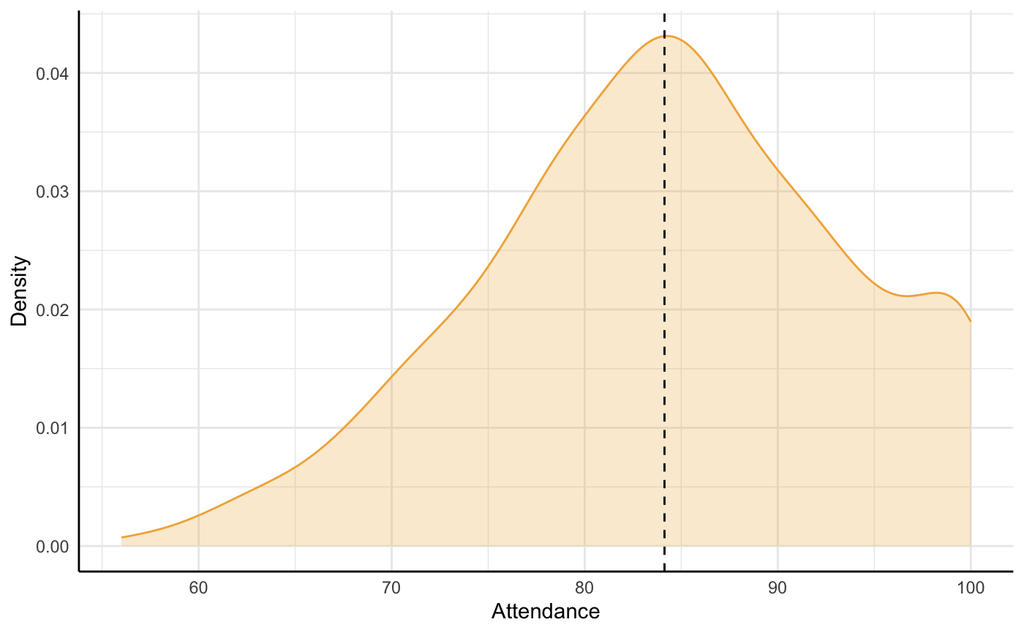

```r
ggplot(data = dt_students, aes(x = attendance_percentage)) +
  geom_density(fill="#f1b147", color="#f1b147", alpha=0.25) +
  labs(
    x = 'Attendance',
    y = 'Density'
  ) +
  geom_vline(xintercept = mean(dt_students$attendance_percentage), linetype="dashed") +
  theme_minimal() +
  theme(axis.line = element_line(color = "#000000"))
```

Age density:

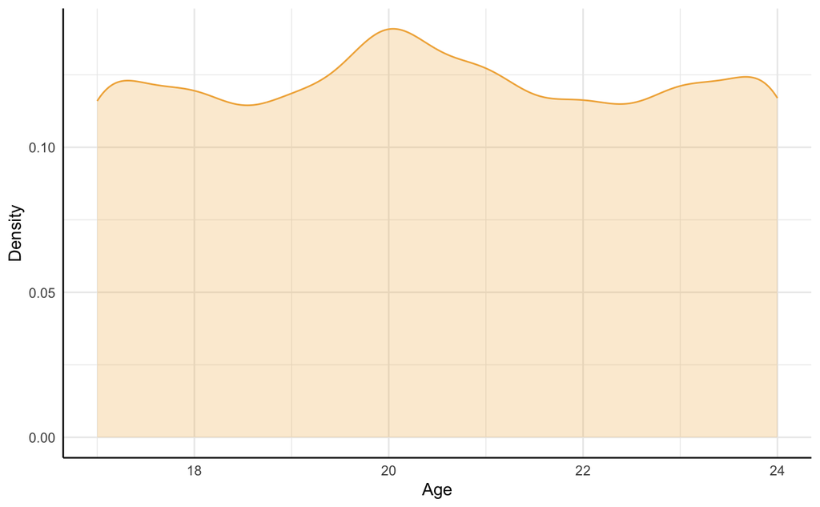

```r
ggplot(data = dt_students, aes(x = age)) +
  geom_density(fill="#f1b147", color="#f1b147", alpha=0.25) +
  labs(
    x = 'Age',
    y = 'Density'
  ) +
  theme_minimal() +
  theme(axis.line = element_line(color = "#000000"))
```

Age density plot looks pretty well distributed, so I think there is a better chance to learn good model from this dataset and generalize well.

Next plot will visualize the distribution of exam scores depending on attendance, and I would like to take a look at how possibly hours studied per day affect the exam score.

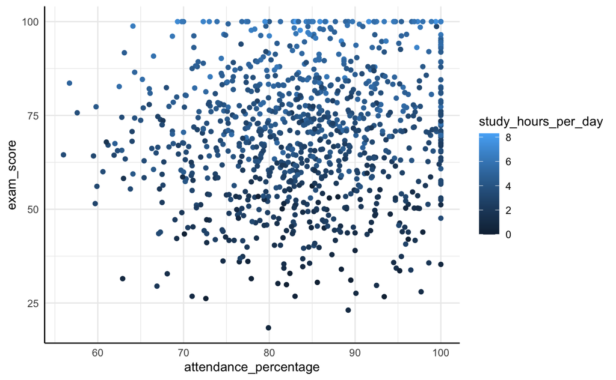

```r
ggplot() +
  geom_point(data = dt_students, aes(x = attendance_percentage, y = exam_score, color = study_hours_per_day)) +
  theme_minimal() +
  theme(axis.line = element_line(color = "#000000"))
```

This scatter plot visualizes the relationship between attendance percentage (x-axis) and exam score (y-axis), with color indicating the amount of hours studied per day. It shows a positive correlation between high attendance, more study hours per day and exam score. I would say that on average students, who learn and attend classes more tend to get better scores. However, there is some variability, as some students with attendance more than 85% and average studying hours get worst scores.

The next plot, which I am going to do is a boxplot and I want to use diet quality as a factor variable on x axis and exam score on y-axis, to get an overall understanding, how the diet quality may affect the exam score.

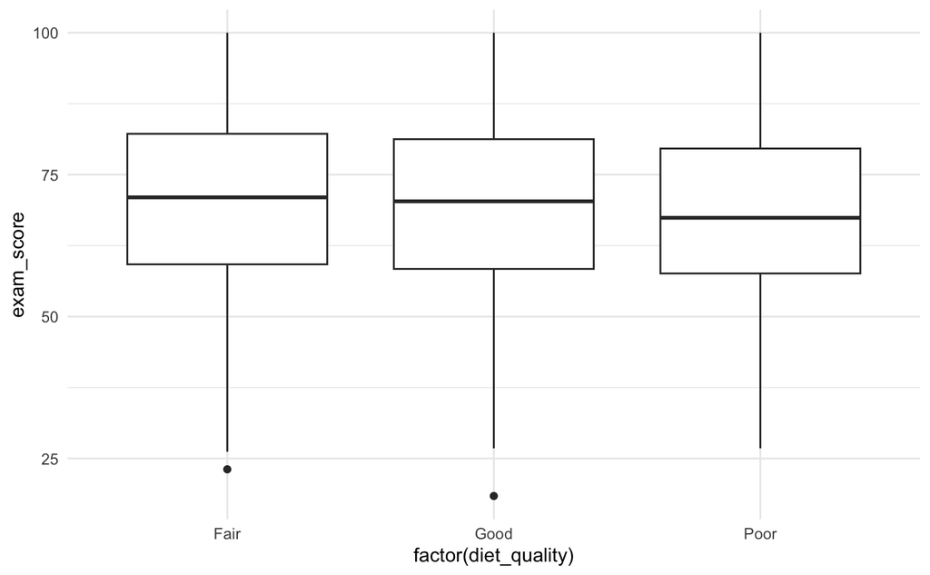

```r
ggplot(data = dt_students, aes(x = factor(diet_quality), y = exam_score)) +
  geom_boxplot() +
  theme_minimal()
```

Boxplot shows that diet quality could be not a very valuable predictor variable. But, we can see, that poor diet has a little bit lower performance. From my personal opinion this difference is so statistically low, that it will not play a big role, but this is still interesting, that If person wants to get the best performance, it is also important to get “the best fuel”.

Another very important thing is sleep. I would like to know if there is visible relation between sleep, exercise frequency and exam score, and also sleep distribution of the students.

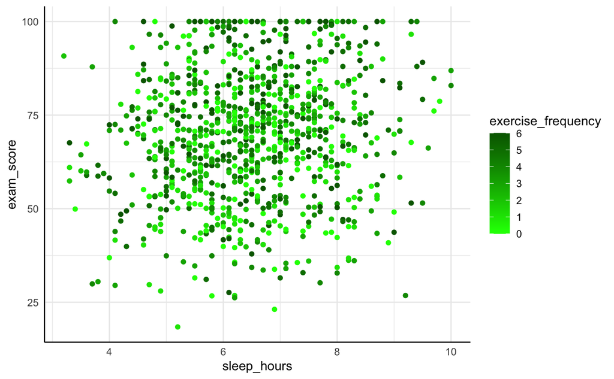

```r
ggplot(data = dt_students, aes(x = sleep_hours, y = exam_score, colour = exercise_frequency)) +
  geom_point() +
  theme_minimal() +
  theme(axis.line = element_line(color = "#000000")) +
  scale_colour_gradient(low = "green", high = "darkgreen")
```

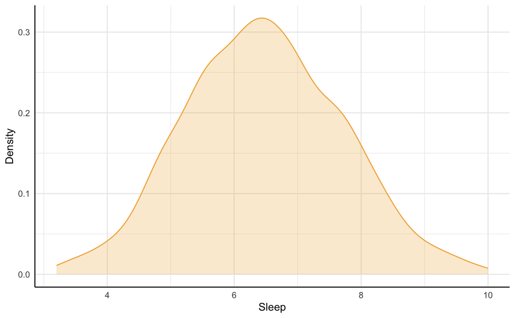

```r
ggplot(data = dt_students, aes(x = sleep_hours)) +
  geom_density(fill="#f1b147", color="#f1b147", alpha=0.25) +
  labs(
    x = 'Sleep',
    y = 'Density'
  ) +
  theme_minimal() +
  theme(axis.line = element_line(color = "#000000"))
```

From this two plots it is clear that it is not very clear that sleep and sport play a very important role, because there are students who sleep, does sports and gets great scores, but also students, who does not sleep as much, and doesn’t so much of a sport, but still gets good grades. Even some Students with 4.5 hours and 1 workaout a week are getting 100% exam score.

Let’s create one more boxplot to look at average notes of students with and without part time jobs:

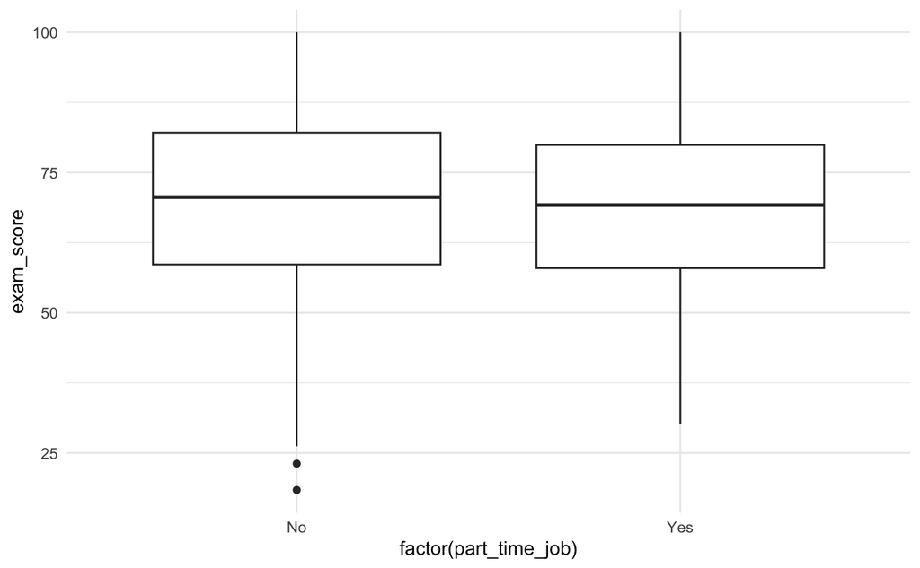

```r
ggplot(data = dt_students, aes(x = factor(part_time_job), y = exam_score)) +
  geom_boxplot() +
  theme_minimal()
```

Boxplot shows some little difference, but as i thought it is roughly the same.

Now I would like to take a look at one more scatter plot with amount of social media hours with exam score and gender.

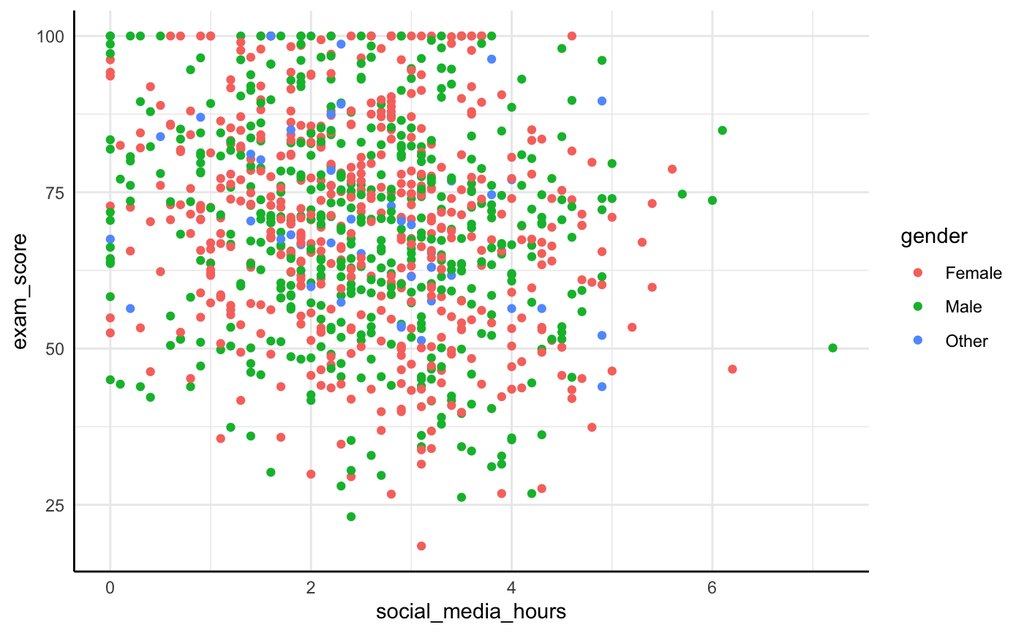

```r
ggplot( data = dt_students, aes(x = social_media_hours, y = exam_score, colour = gender)) +
  geom_point() +
  theme_minimal() +
  theme(axis.line = element_line(color = "#000000"))
```

I would say that I expected another result, but it seems, that on average amount of social media usage does not play a very big role, but it is also an slight average better to spend less time on social media to get better scores.

One last plot will include mental health rating, which from my point of view is very important to perform well.

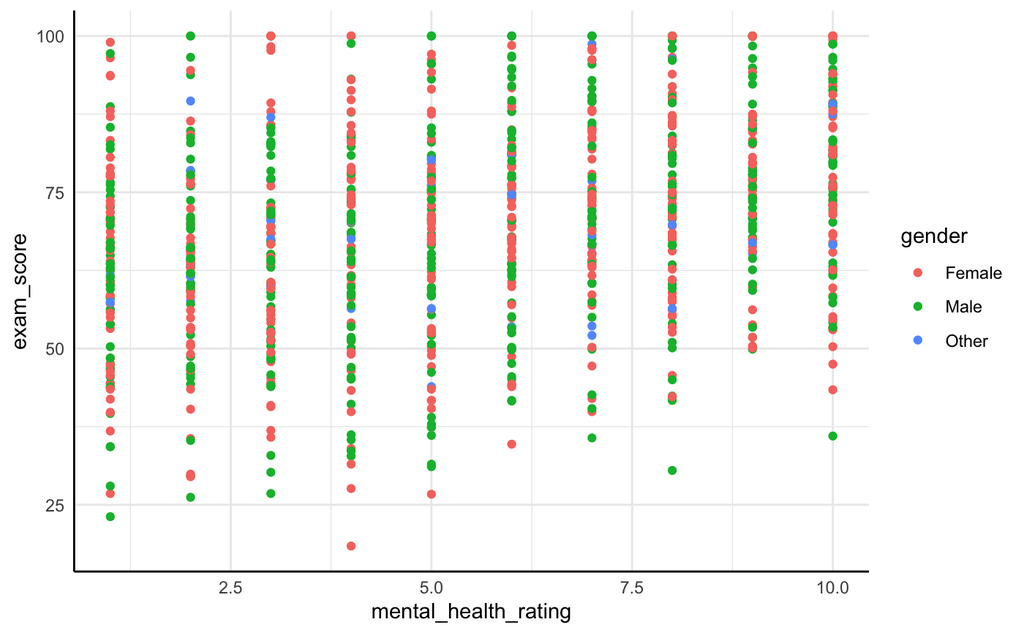

```r
ggplot(data = dt_students, aes(x = mental_health_rating, y = exam_score, colour = gender)) +
  geom_point() +
  theme_minimal() +
  theme(axis.line = element_line(color = "#000000"))
```

This plot does not provide enough information, so let’s take a look on a vertical barchart.

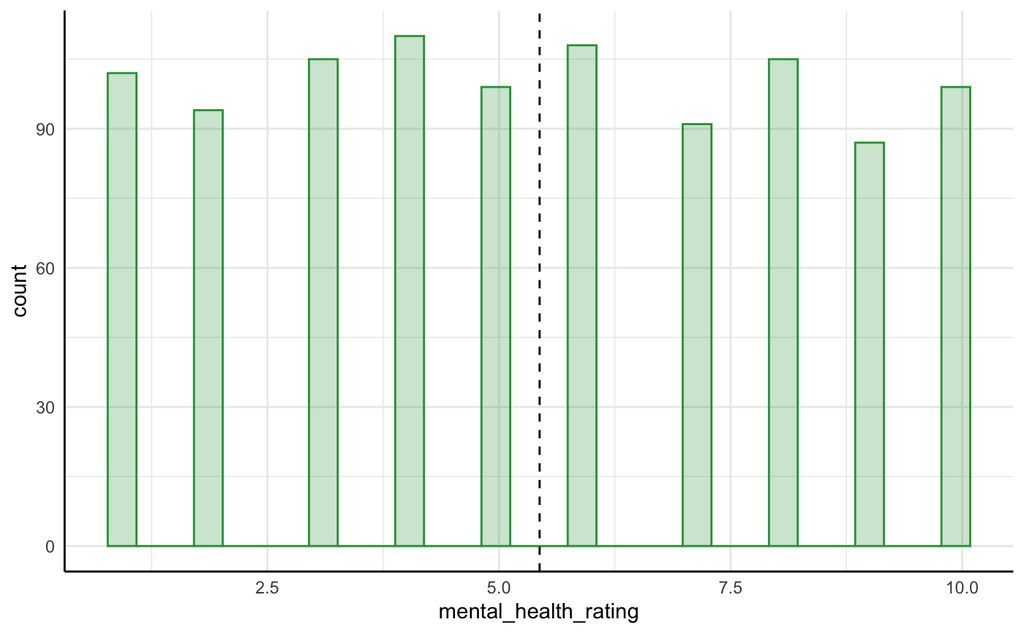

```r
ggplot(data = dt_students, aes(x = mental_health_rating)) +
  geom_histogram(fill="#2f9e44", color="#2f9e44", alpha=0.25) +
  geom_vline(xintercept = mean(dt_students$mental_health_rating), linetype="dashed") +
  theme_minimal() +
  theme(axis.line = element_line(color = "#000000"))
```

```r
mean(dt_students$mental_health_rating)
```

```
[1] 5.438
```

Okay, from the last 2 plots I could conclude, that mental health could possibly better results on average, but students can still perform well, while being in a “bad” mood.

I think that would be enough exploration and we can start with models.

# Models 1 & 2

Now the interesting part! So before I start, I want to split my data to training and test datasets. I will use *CARET* for almost every operation, because it is convenient and smart.

## Precomputing

splitting my data and creating factors:

```r
set_seed_for_random_state()

dt_students$gender <- as.factor(dt_students$gender)
dt_students$part_time_job <- as.factor(dt_students$part_time_job)
dt_students$diet_quality <- as.factor(dt_students$diet_quality)
dt_students$parental_education_level <- as.factor(dt_students$parental_education_level)
dt_students$internet_quality <- as.factor(dt_students$internet_quality)
dt_students$extracurricular_participation <- as.factor(dt_students$extracurricular_participation)

dt_train <- createDataPartition(
  y = dt_students$exam_score,
  p = 0.8,
  list = FALSE
)

dt_students_train <- dt_students[dt_train,]
dt_students_test <- dt_students[-dt_train,]
```

## Linear model

So now that we have splitted the data, we can start with Linear model. I would like to use ten-fold Cross validation, as it from my personal research is a standard in data science, and repeat it 10 times.

```r
set_seed_for_random_state()

train_control <- trainControl(method = "repeatedcv", number = 10, repeats = 10)

lm_scores <- caret::train(exam_score ~ .,
                   data = dt_students_train[, -"student_id"],
                   method = "lm",
                   trControl = train_control,
                   preProcess = c("center","scale"))

summary(lm_scores)
```

```
Call:
lm(formula = .outcome ~ ., data = dat)

Residuals:
     Min       1Q   Median       3Q      Max
-21.9631  -3.3598   0.1468   3.3744  15.2572

Coefficients:
                                       Estimate Std. Error t value Pr(>|t|)
(Intercept)                           69.519725   0.185853 374.058  < 2e-16 ***
age                                    0.078992   0.187051   0.422    0.673
genderMale                             0.013532   0.191512   0.071    0.944
genderOther                            0.122279   0.191077   0.640    0.522
study_hours_per_day                   14.066987   0.187369  75.076  < 2e-16 ***
social_media_hours                    -3.052034   0.187596 -16.269  < 2e-16 ***
netflix_hours                         -2.503528   0.186627 -13.415  < 2e-16 ***
part_time_jobYes                       0.002845   0.187775   0.015    0.988
attendance_percentage                  1.481166   0.188472   7.859 1.28e-14 ***
sleep_hours                            2.379844   0.187594  12.686  < 2e-16 ***
diet_qualityGood                      -0.223157   0.200392  -1.114    0.266
diet_qualityPoor                       0.046765   0.200502   0.233    0.816
exercise_frequency                     2.993176   0.187186  15.990  < 2e-16 ***
`parental_education_levelHigh School`  0.024045   0.214345   0.112    0.911
parental_education_levelMaster        -0.055873   0.209929  -0.266    0.790
parental_education_levelNone          -0.201652   0.201363  -1.001    0.317
internet_qualityGood                  -0.237131   0.203111  -1.167    0.243
internet_qualityPoor                  -0.093088   0.202764  -0.459    0.646
mental_health_rating                   5.446537   0.188278  28.928  < 2e-16 ***
extracurricular_participationYes       0.075877   0.187731   0.404    0.686
---
Signif. codes:  0 ‘***’ 0.001 ‘**’ 0.01 ‘*’ 0.05 ‘.’ 0.1 ‘ ’ 1

Residual standard error: 5.26 on 781 degrees of freedom
Multiple R-squared:  0.905, Adjusted R-squared:  0.9027
F-statistic: 391.7 on 19 and 781 DF,  p-value: < 2.2e-16
```

R^2 of 0.9 looks great and now I would like to calculate MSE and then CV MSE.

Training MSE:

```r
set_seed_for_random_state()

scores_lm_train_predictions <- predict(lm_scores, newdata = dt_students_train)

lm_train_mse <- mean((dt_students_train$exam_score - scores_lm_train_predictions)^2)
cat("Training MSE:", lm_train_mse, "\n")
```

```
Training MSE: 26.97676
```

We can pull RMSE from CV

```r
lm_scores$results
```

|  | intercept | RMSE | Rsquared | MAE | RMSESD | RsquaredSD | MAESD |
| --- | --- | --- | --- | --- | --- | --- | --- |
| 1 | TRUE | 5.317515 | 0.9018214 | 4.230202 | 0.4579642 | 0.01779719 | 0.3577715 |

calculate MSE:

```r
lm_cv_mse <- lm_scores$results$RMSE^2
cat("Cross-Validation MSE:", lm_cv_mse)
```

```
Cross-Validation MSE: 28.27596
```

## Tree Model

I think this model could perform better, because there some variables which can affect this model not only linearly, but the other way, in this case tree model can show better performance.

```r
set_seed_for_random_state()

dt_students_train_copy <- copy(dt_students_train)
X_train <- as.data.frame(dt_students_train_copy[, -c("student_id", "exam_score")])
Y_train <- dt_students_train_copy$exam_score

train_control <- trainControl(method = "repeatedcv",
                              number = 10,
                              repeats = 10
                              )

# I will let caret to test 20 different cp values
scores_tree <- caret::train(
  x = X_train,
  y = Y_train,
  method = "rpart",
  trControl = train_control,
  tuneLength = 20
)
# print the model
print(scores_tree)
```

```
CART

801 samples
 14 predictor

No pre-processing
Resampling: Cross-Validated (10 fold, repeated 10 times)
Summary of sample sizes: 720, 720, 721, 721, 721, 721, ...
Resampling results across tuning parameters:

  cp           RMSE       Rsquared   MAE
  0.003282682   8.717758  0.7360713   7.029299
  0.003900417   8.760777  0.7334184   7.066323
  0.003922311   8.762393  0.7333052   7.069097
  0.003969398   8.768683  0.7328460   7.075595
  0.004549471   8.800330  0.7306733   7.112123
  0.004865958   8.816580  0.7297778   7.138797
  0.005006914   8.823465  0.7291762   7.152486
  0.005949731   8.898326  0.7243175   7.230839
  0.006423452   8.948607  0.7211568   7.277803
  0.008062325   9.031124  0.7153676   7.351335
  0.008223434   9.029764  0.7153383   7.352442
  0.009723425   9.171102  0.7059045   7.461422
  0.010649503   9.238672  0.7018082   7.514492
  0.012931690   9.396999  0.6919052   7.613344
  0.018206189   9.508959  0.6842799   7.721805
  0.030116704  10.063739  0.6467416   8.256074
  0.032384199  10.331782  0.6279239   8.453804
  0.077073707  11.144878  0.5675764   9.043991
  0.101610936  11.696978  0.5224032   9.512577
  0.458950809  14.630838  0.4091530  11.889247

RMSE was used to select the optimal model using the smallest value.
The final value used for the model was cp = 0.003282682.
```

I want also find out which cp values were used, and which is chosen

```r
best_cp <- scores_tree$bestTune$cp
cat("Best CP:", best_cp, "\n")
```

```
Best CP: 0.003282682
```

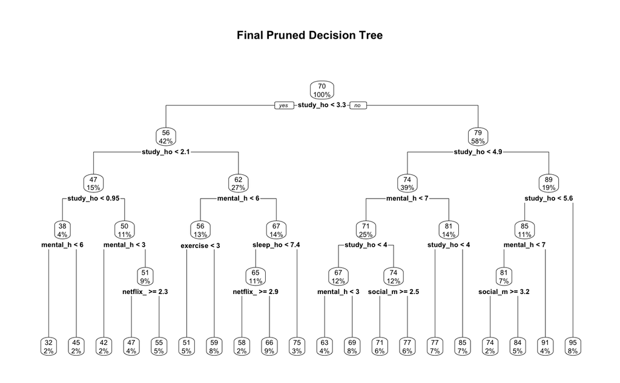

```r
final_scores_tree <- scores_tree$finalModel

prp(final_scores_tree, type = 2, extra = 100, fallen.leaves = TRUE, main = "Final Pruned Decision Tree")
```

One great thing about caret is that it prunes the tree itself, only one thing I need to do is to set how many different *cp* should caret try. So now I can calculate MSE for training, CV and test dataset.

So now I can calculate Trainig and CV loss:

```r
# training MSE
train_predictions_tree <- predict(scores_tree, newdata = dt_students_train[,-"student_id"])

# Calculate Training MSE
tree_train_mse <- mean((dt_students_train$exam_score - train_predictions_tree)^2)
cat("Tree Model Training MSE:", tree_train_mse, "\n")
```

```
Tree Model Training MSE: 54.95817
```

```r
# Extract the RMSE from that row and square it to get MSE
cv_rmse_tree <- scores_tree$results$RMSE[scores_tree$results$cp == best_cp]
tree_cv_mse <- cv_rmse_tree^2
cat("Tree Model Cross-Validation MSE:", tree_cv_mse, "\n")
```

```
Tree Model Cross-Validation MSE: 75.99931
```

And let’s calculate MSE on a test set:

```r
# test MSE
test_predictions_tree <- predict(scores_tree, newdata = dt_students_test[, -"student_id"])

# calculate testing MSE
tree_test_mse <- mean((dt_students_test$exam_score - test_predictions_tree)^2)
cat("Tree Model Testing MSE:", tree_test_mse, "\n")
```

```
Tree Model Testing MSE: 75.75831
```

## Comparing

So after training and testing linear and decisions tree models, it is time to compare their performance.

### Linear model performance

```r
print_results(lm_train_mse, lm_cv_mse)
```

```
Training MSE:  26.97676
CV Loss:  28.27596
```

### Tree model performance

```r
print_results(tree_train_mse, tree_cv_mse)
```

```
Training MSE:  54.95817
CV Loss:  75.99931
```

I will compare all models based on CV loss, so let’s start with linear and tree model. This is a small plot to represent visually the difference in performance:

[figure not shown]

```r
values <- c(lm_cv_mse, tree_cv_mse)
custom_labels <- c("Linear model", "Tree model")

data_for_plot <- data.frame(
  ID = as.factor(custom_labels),
  Value = values
)

ggplot(data_for_plot, aes(x = ID, y = Value)) +
  geom_col(fill = "#69db7c") +
  labs(
    title = "Test Loss of 4 models",
    x = "Model name",
    y = "Loss"
  ) +
  theme_minimal() +
  theme(
    plot.title = element_text(hjust = 0.5, size = 16, face = "bold"),
    axis.title = element_text(size = 12),
    axis.text = element_text(size = 10),
    panel.grid.major.x = element_blank(),
    panel.grid.minor.y = element_blank()
  )
```

The linear model performs better than the tree model, and I suppose this is because my dataset is synthetic and was created for a regression problem. It is possible, therefore, that the linear model will perform best overall.

# Ensemble 1

Now it is time to upgrade decisions tree to a random forest. I will be using caret for model creation and evaluation.

## Preparation

Before I start with random forest, I need to prepare my hyperparametrs. There are 2 main hyperparameters:

- ntree, number of trees grown
- mtry, number of variables used

I create grid, with all possible combinations of hyperparameters

```r
# preparing the grid for caret
rf_grid <- data.table("mtry"=1:(ncol(dt_students_train)-1))
```

## Training

Now, as I have my hyperparameters, it is time to try it in caret.

```r
set_seed_for_random_state()

# control settings
train_control_rf <- trainControl(method = "cv", number = 10)

rf_scores <- caret::train(exam_score ~ ., data = dt_students_train[, -"student_id"],
                   method="rf",
                   ntrees=500,
                   trControl = train_control_rf,
                   search = "grid",
                   tuneGrid = rf_grid,
                   preProcess = c("center","scale"))

rf_scores
```

```
Random Forest

801 samples
 14 predictor

Pre-processing: centered (19), scaled (19)
Resampling: Cross-Validated (10 fold)
Summary of sample sizes: 720, 720, 721, 721, 721, 721, ...
Resampling results across tuning parameters:

  mtry  RMSE       Rsquared   MAE
   1    13.789965  0.7724270  10.975227
   2    10.559136  0.8330706   8.412292
   3     8.879897  0.8575322   7.099124
   4     7.893836  0.8657034   6.345343
   5     7.250631  0.8712865   5.822263
   6     6.841255  0.8738798   5.515512
   7     6.568121  0.8746808   5.322499
   8     6.405348  0.8746914   5.198394
   9     6.306902  0.8744595   5.121656
  10     6.249268  0.8728592   5.099035
  11     6.200252  0.8731381   5.039273
  12     6.186711  0.8719529   5.042807
  13     6.154305  0.8721824   4.993584
  14     6.177156  0.8704542   5.004883
  15     6.177622  0.8695811   5.016225

RMSE was used to select the optimal model using the smallest value.
The final value used for the model was mtry = 13.
```

## Evaluation

Okay, the best mtry value is 13, so I will use this model in my course work. Now I would like to calculate training MSE

```r
# calculating training MSE
train_predictions_rf <- predict(rf_scores, newdata = dt_students_train[, -"student_id"])

rf_train_mse <- mean((dt_students_train$exam_score - train_predictions_rf)^2)

cat("Random Forest Training MSE:", rf_train_mse)
```

```
Random Forest Training MSE: 6.788726
```

```r
# Cross Validation MSE
optimal_rf <- rf_scores$results[rf_scores$results$mtry == rf_scores$bestTune$mtry, ]
rf_cv_mse <- optimal_rf$RMSE^2
print(paste("Cross-validation MSE for the optimal mtry (", rf_scores$bestTune$mtry, "):", rf_cv_mse))
```

```
[1] "Cross-validation MSE for the optimal mtry ( 13 ): 37.8754723821131"
```

So, after I trained 500 trees with hyperparameter mtry = 13 I got Train MSE ~6, which is so much better than a decision tree, but the CV value is ~38.

# Ensemble 2

## Training

As my second ensemble I would like to use Gradient Boosting. I will also use caret to train and cross validate this model.

Let’s start with training:

```r
train_control_boosting <- trainControl(method = "cv", number = 10)

gbm_grid =  expand.grid(interaction.depth = 1:5,
                        n.trees = c(500,1000,2000,5000),
                        shrinkage = c(0.1, 0.01, 0.001),
                        n.minobsinnode = c(10,20))

caret_gbm <- caret::train(exam_score ~ ., data = dt_students_train[,-"student_id"],
                     method = "gbm",
                     trControl = train_control_boosting,
                     tuneGrid = gbm_grid,
                     verbose = FALSE)

head(caret_gbm$results)
```

|  | shrinkage | interaction.depth | n.minobsinnode | n.trees | RMSE | Rsquared | MAE | RMSESD | RsquaredSD | MAESD |
| --- | --- | --- | --- | --- | --- | --- | --- | --- | --- | --- |
| 1 | 0.001 | 1 | 10 | 500 | 14.011058 | 0.5743990 | 11.171510 | 0.7735823 | 0.06382586 | 0.5689003 |
| 5 | 0.001 | 1 | 20 | 500 | 14.015309 | 0.5727937 | 11.173570 | 0.7739448 | 0.06226224 | 0.5694040 |
| 41 | 0.010 | 1 | 10 | 500 | 8.056196 | 0.8084030 | 6.496435 | 0.6389487 | 0.03150721 | 0.5954041 |
| 45 | 0.010 | 1 | 20 | 500 | 8.078765 | 0.8058268 | 6.520731 | 0.6304595 | 0.03055674 | 0.6097710 |
| 81 | 0.100 | 1 | 10 | 500 | 5.327710 | 0.9015567 | 4.301805 | 0.5135679 | 0.01544422 | 0.3406064 |
| 85 | 0.100 | 1 | 20 | 500 | 5.340704 | 0.9004564 | 4.314371 | 0.5022961 | 0.01498849 | 0.3647439 |

This is a sample of all results, which caret has after training and evaluating the Gradinet boosting model.

And the best Model has these hyperparameters:

```r
caret_gbm$bestTune
```

|  | n.trees | interaction.depth | shrinkage | n.minobsinnode |
| --- | --- | --- | --- | --- |
| 51 | 2000 | 2 | 0.01 | 10 |

## Evaluation

And as always, calcualting training loss and CV loss.

Calculating training MSE:

```r
set_seed_for_random_state()

boosting_predictions <- predict(caret_gbm, newdata = dt_students_train)

boosting_train_mse <- mean((dt_students_train$exam_score - boosting_predictions)^2)

cat("Boosting training MSE: ", boosting_train_mse)
```

```
Boosting training MSE:  18.79738
```

Calculating CV loss:

```r
boosting_cv_mse <- caret_gbm$results[which.min(caret_gbm$results$RMSE), "RMSE"]^2

cat("Boosting CV loss: ", boosting_cv_mse)
```

```
Boosting CV loss:  27.34127
```

This model performs better than linear model, but only by a little margin.

# Model Comparison

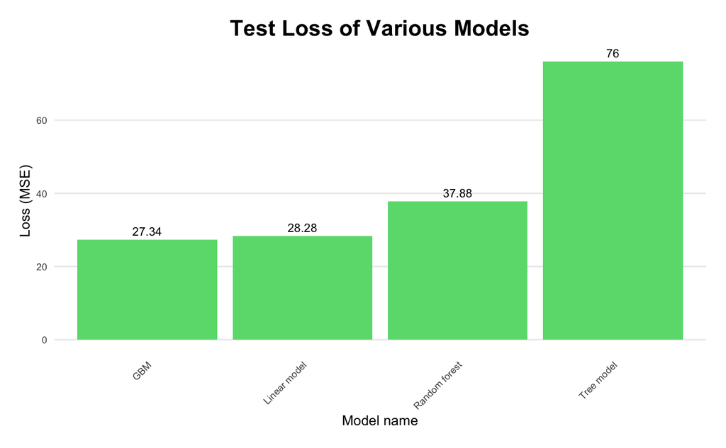

```r
values <- c(lm_cv_mse, tree_cv_mse, rf_cv_mse, boosting_cv_mse)
custom_labels <- c("Linear model", "Tree model", "Random forest", "GBM")

data_for_plot <- data.frame(
  ID = as.factor(custom_labels),
  Value = values
)

ggplot(data_for_plot, aes(x = ID, y = Value)) +
  geom_col(fill = "#69db7c") +
  geom_text(aes(label = round(Value, 2)),
            vjust = -0.5,
            size = 3) +
  labs(
    title = "Test Loss of Various Models",
    x = "Model name",
    y = "Loss (MSE)"
  ) +
  theme_minimal() +
  theme(
    plot.title = element_text(hjust = 0.5, size = 16, face = "bold"),
    axis.title = element_text(size = 10),
    axis.text.x = element_text(size = 7, angle = 45, hjust = 1),
    axis.text.y = element_text(size = 7),
    panel.grid.major.x = element_blank(),
    panel.grid.minor.y = element_blank(),
    plot.margin = unit(c(1, 1, 1, 1), "lines")
  )
```

One more thing, that is also interesting for me is training loss:

[figure not shown]

```r
values <- c(lm_train_mse, tree_train_mse, rf_train_mse, boosting_train_mse)
custom_labels <- c("Linear model", "Tree model", "Random forest", "GBM")

data_for_plot <- data.frame(
  ID = as.factor(custom_labels),
  Value = values
)

ggplot(data_for_plot, aes(x = ID, y = Value)) +
  geom_col(fill = "#69db7c") +
  geom_text(aes(label = round(Value, 2)),
            vjust = -0.5,
            size = 3) +
  labs(
    title = "Test Loss of Various Models",
    x = "Model name",
    y = "Loss (MSE)"
  ) +
  theme_minimal() +
  theme(
    plot.title = element_text(hjust = 0.5, size = 16, face = "bold"),
    axis.title = element_text(size = 10),
    axis.text.x = element_text(size = 7, angle = 45, hjust = 1),
    axis.text.y = element_text(size = 7),
    panel.grid.major.x = element_blank(),
    panel.grid.minor.y = element_blank(),
    plot.margin = unit(c(1, 1, 1, 1), "lines")
  )
```

The behavior of the Random Forest model is particularly surprising. While Random Forests are typically employed to mitigate variance, it notably exhibited the lowest training loss among all models, and by a significant margin.

# PCA

After very interesting investigation and comparison of 4 models, I would like to run PCA and compare CV loss from the all models again.

## Linear model

To train models after PCA, I will add “pca” in pre process of caret.

```r
set_seed_for_random_state()

train_control <- trainControl(method = "repeatedcv", number = 10, repeats = 10)

lm_pca_scores <- caret::train(exam_score ~ .,
                   data = dt_students_train[, -"student_id"],
                   method = "lm",
                   trControl = train_control,
                   preProcess = c("center","scale", "pca"))

summary(lm_pca_scores)
```

```
Call:
lm(formula = .outcome ~ ., data = dat)

Residuals:
     Min       1Q   Median       3Q      Max
-22.1598  -3.4271   0.2305   3.3341  15.4201

Coefficients:
            Estimate Std. Error t value Pr(>|t|)
(Intercept)  69.5197     0.1859 373.945  < 2e-16 ***
PC1          -1.3677     0.1522  -8.987  < 2e-16 ***
PC2          -0.1502     0.1550  -0.969 0.332961
PC3           0.4482     0.1613   2.779 0.005586 **
PC4           2.0022     0.1672  11.977  < 2e-16 ***
PC5          -1.8485     0.1734 -10.660  < 2e-16 ***
PC6           2.7619     0.1768  15.617  < 2e-16 ***
PC7           3.0045     0.1793  16.756  < 2e-16 ***
PC8          -0.7040     0.1809  -3.891 0.000108 ***
PC9           7.9819     0.1825  43.730  < 2e-16 ***
PC10          4.0506     0.1839  22.021  < 2e-16 ***
PC11         -8.4185     0.1869 -45.031  < 2e-16 ***
PC12          6.1782     0.1911  32.329  < 2e-16 ***
PC13         -3.0734     0.1934 -15.894  < 2e-16 ***
PC14          4.1789     0.1955  21.377  < 2e-16 ***
PC15         -2.8171     0.2017 -13.968  < 2e-16 ***
PC16         -1.7512     0.2119  -8.263 6.05e-16 ***
PC17          1.1326     0.2367   4.785 2.04e-06 ***
PC18          2.2349     0.2436   9.174  < 2e-16 ***
---
Signif. codes:  0 ‘***’ 0.001 ‘**’ 0.01 ‘*’ 0.05 ‘.’ 0.1 ‘ ’ 1

Residual standard error: 5.262 on 782 degrees of freedom
Multiple R-squared:  0.9048,    Adjusted R-squared:  0.9027
F-statistic: 413.1 on 18 and 782 DF,  p-value: < 2.2e-16
```

And small overview of train and CV loss:

```r
# Training MSE
lm_pca_train_predictions <- predict(lm_pca_scores, newdata = dt_students_train[, -"student_id"])
lm_pca_train_mse <- mean((dt_students_train$exam_score - lm_pca_train_predictions)^2)
cat("LM PCA Training MSE:", lm_pca_train_mse, "\n")
```

```
LM PCA Training MSE: 27.02764
```

```r
# CV MSE
lm_pca_cv_mse <- lm_pca_scores$results$RMSE^2
cat("LM PCA Cross-Validation MSE:", lm_pca_cv_mse, "\n")
```

```
LM PCA Cross-Validation MSE: 28.26246
```

## Tree model

There will be a similar process to a previous decision tree model, but now I will also add “pca” paramenter in pre process:

```r
set_seed_for_random_state()

train_control <- trainControl(method = "repeatedcv",
                              number = 10,
                              repeats = 10)

scores_tree_pca <- caret::train(
  x = X_train,
  y = Y_train,
  method = "rpart",
  trControl = train_control,
  tuneLength = 20,
  preProcess = c("center","scale", "pca")
)
print(scores_tree_pca)
```

```
CART

801 samples
 14 predictor

Pre-processing: centered (8), scaled (8), principal component signal extraction (8), ignore (6)
Resampling: Cross-Validated (10 fold, repeated 10 times)
Summary of sample sizes: 720, 720, 721, 721, 721, 721, ...
Resampling results across tuning parameters:

  cp           RMSE      Rsquared   MAE
  0.003282682  11.01384  0.5858606   8.831797
  0.003900417  11.08262  0.5798778   8.870780
  0.003922311  11.08244  0.5798371   8.869828
  0.003969398  11.09332  0.5789251   8.888101
  0.004549471  11.18848  0.5711284   8.970646
  0.004865958  11.23319  0.5674095   9.000244
  0.005006914  11.25131  0.5655073   9.012951
  0.005949731  11.31981  0.5584218   9.083862
  0.006423452  11.34550  0.5556394   9.122884
  0.008062325  11.56229  0.5375784   9.294762
  0.008223434  11.58676  0.5353731   9.313859
  0.009723425  11.65395  0.5291055   9.393400
  0.010649503  11.73756  0.5223240   9.463293
  0.012931690  11.86871  0.5100518   9.570963
  0.018206189  12.22323  0.4799502   9.866122
  0.030116704  12.75686  0.4321610  10.320502
  0.032384199  12.86287  0.4224023  10.395032
  0.077073707  13.91181  0.3227704  11.328142
  0.101610936  14.42403  0.2737720  11.766348
  0.458950809  16.80287  0.4130723  13.526698

RMSE was used to select the optimal model using the smallest value.
The final value used for the model was cp = 0.003282682.
```

Train and CV loss:

```r
# Training MSE
tree_pca_train_predictions <- predict(scores_tree_pca, newdata = dt_students_train[, -"student_id"])
tree_pca_train_mse <- mean((dt_students_train$exam_score - tree_pca_train_predictions)^2)
cat("Tree PCA Training MSE:", tree_pca_train_mse, "\n")
```

```
Tree PCA Training MSE: 60.26595
```

```r
# CV MSE
best_cp_pca <- scores_tree_pca$bestTune$cp
cv_rmse_tree_pca <- scores_tree_pca$results$RMSE[scores_tree_pca$results$cp == best_cp_pca]
tree_pca_cv_mse <- cv_rmse_tree_pca^2
cat("Tree PCA Cross-Validation MSE:", tree_pca_cv_mse, "\n")
```

```
Tree PCA Cross-Validation MSE: 121.3047
```

## Random forest

Here PCA will be also implemented with help of the caret pre process parameter:

```r
set_seed_for_random_state()

# control settings
train_control_rf <- trainControl(method = "cv", number = 10)

rf_pca_scores <- caret::train(exam_score ~ ., data = dt_students_train[, -"student_id"],
                   method="rf",
                   ntrees=500,
                   trControl = train_control_rf,
                   search = "grid",
                   tuneGrid = rf_grid,
                   preProcess = c("center","scale", "pca"))

rf_pca_scores
```

```
Random Forest

801 samples
 14 predictor

Pre-processing: centered (19), scaled (19), principal component signal extraction (19)
Resampling: Cross-Validated (10 fold)
Summary of sample sizes: 720, 720, 721, 721, 721, 721, ...
Resampling results across tuning parameters:

  mtry  RMSE       Rsquared   MAE
   1    12.049359  0.7936943  9.716127
   2    10.627262  0.8221404  8.525806
   3     9.938912  0.8192279  7.964906
   4     9.482641  0.8152777  7.562294
   5     9.272723  0.8030068  7.404370
   6     9.105981  0.7966817  7.246550
   7     8.985914  0.7916927  7.149759
   8     8.955291  0.7845927  7.116766
   9     8.911572  0.7775433  7.070355
  10     8.902979  0.7745843  7.067693
  11     8.943595  0.7664147  7.089737
  12     8.914206  0.7649478  7.070199
  13     8.984612  0.7575775  7.123551
  14     8.938849  0.7585684  7.069729
  15     8.986488  0.7534184  7.110275

RMSE was used to select the optimal model using the smallest value.
The final value used for the model was mtry = 10.
```

Train and CV loss:

```r
# Training MSE
train_predictions_rf_pca <- predict(rf_pca_scores, newdata = dt_students_train[, -"student_id"])
rf_pca_train_mse <- mean((dt_students_train$exam_score - train_predictions_rf_pca)^2)
cat("RF PCA Training MSE:", rf_pca_train_mse, "\n")
```

```
RF PCA Training MSE: 13.42379
```

```r
# Cross Validation MSE
optimal_rf_pca <- rf_pca_scores$results[rf_pca_scores$results$mtry == rf_pca_scores$bestTune$mtry, ]
rf_pca_cv_mse <- optimal_rf_pca$RMSE^2
cat("RF PCA Cross-validation MSE for optimal mtry (", rf_pca_scores$bestTune$mtry, "):", rf_pca_cv_mse)
```

```
RF PCA Cross-validation MSE for optimal mtry ( 10 ): 79.26303
```

## Gradinet Boosting

Here the procedure is the same as above:

```r
train_control_boosting <- trainControl(method = "cv", number = 10)

gbm_grid =  expand.grid(interaction.depth = 1:5,
                        n.trees = c(500,1000,2000,5000),
                        shrinkage = c(0.1, 0.01, 0.001),
                        n.minobsinnode = c(10,20))

boosting_scores_pca <- caret::train(exam_score ~ ., data = dt_students_train[,-"student_id"],
                     method = "gbm",
                     trControl = train_control_boosting,
                     tuneGrid = gbm_grid,
                     preProcess = c("center","scale", "pca"),
                     verbose = FALSE)

head(boosting_scores_pca$results)
```

|  | shrinkage | interaction.depth | n.minobsinnode | n.trees | RMSE | Rsquared | MAE | RMSESD | RsquaredSD | MAESD |
| --- | --- | --- | --- | --- | --- | --- | --- | --- | --- | --- |
| 1 | 0.001 | 1 | 10 | 500 | 15.651979 | 0.3495662 | 12.603093 | 1.0983322 | 0.16758594 | 0.9718046 |
| 5 | 0.001 | 1 | 20 | 500 | 15.648100 | 0.3518217 | 12.599514 | 1.0977846 | 0.17050960 | 0.9710758 |
| 41 | 0.010 | 1 | 10 | 500 | 10.870392 | 0.6751423 | 8.857636 | 1.2400667 | 0.05840771 | 1.1032681 |
| 45 | 0.010 | 1 | 20 | 500 | 10.885985 | 0.6745450 | 8.880473 | 1.2169550 | 0.05994771 | 1.0692040 |
| 81 | 0.100 | 1 | 10 | 500 | 5.984368 | 0.8773479 | 4.781897 | 0.5998548 | 0.01473337 | 0.5927710 |
| 85 | 0.100 | 1 | 20 | 500 | 6.069366 | 0.8742844 | 4.874563 | 0.5338645 | 0.01465585 | 0.5402470 |

Calculating train and CV loss:

```r
set_seed_for_random_state()

boosting_pca_predictions <- predict(boosting_scores_pca, newdata = dt_students_train[,-"student_id"])

boosting_pca_train_mse <- mean((dt_students_train$exam_score - boosting_pca_predictions)^2)

cat("Boosting training MSE: ", boosting_pca_train_mse)
```

```
Boosting training MSE:  19.17823
```

```r
boosting_pca_cv_mse <- caret_gbm$results[which.min(boosting_scores_pca$results$RMSE), "RMSE"]^2

cat("Boosting CV loss: ", boosting_cv_mse)
```

```
Boosting CV loss:  27.34127
```

This looks very interesting, next, I would like to compare all this models and run one of them on a train test set and look, how good will it generalize.

# Model Selection

First, I would like to start with a chart with all CV loss values:

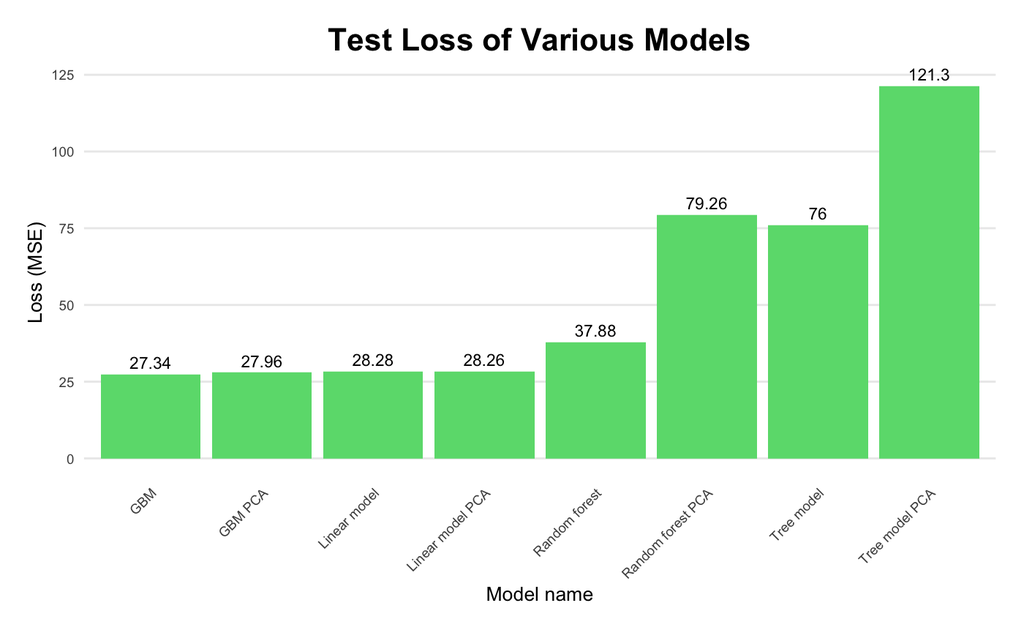

```r
values <- c(lm_cv_mse, tree_cv_mse, rf_cv_mse, boosting_cv_mse, lm_pca_cv_mse, tree_pca_cv_mse, rf_pca_cv_mse, boosting_pca_cv_mse)
custom_labels <- c("Linear model", "Tree model", "Random forest", "GBM", "Linear model PCA", "Tree model PCA", "Random forest PCA", "GBM PCA")

data_for_plot <- data.frame(
  ID = as.factor(custom_labels),
  Value = values
)

ggplot(data_for_plot, aes(x = ID, y = Value)) +
  geom_col(fill = "#69db7c") +
  geom_text(aes(label = round(Value, 2)),
            vjust = -0.5,
            size = 3) +
  labs(
    title = "Test Loss of Various Models",
    x = "Model name",
    y = "Loss (MSE)"
  ) +
  theme_minimal() +
  theme(
    plot.title = element_text(hjust = 0.5, size = 16, face = "bold"),
    axis.title = element_text(size = 10),
    axis.text.x = element_text(size = 7, angle = 45, hjust = 1),
    axis.text.y = element_text(size = 7),
    panel.grid.major.x = element_blank(),
    panel.grid.minor.y = element_blank(),
    plot.margin = unit(c(1, 1, 1, 1), "lines")
  )
```

From the CV loss it is possible to say that GBM without PCA performs the best, but not so much better than simple linear model.

```r
boosting_test_predictions <- predict(caret_gbm, newdata = dt_students_test[, -"student_id"])

boosting_test_mse <- mean((dt_students_test$exam_score - boosting_test_predictions)^2)

cat("GBM test MSE: ", boosting_train_mse)
```

```
GBM test MSE:  18.79738
```

# Conclusion

This project was all about figuring out how things like study habits and lifestyle affect student exam scores.

First, we looked closely at the data to understand things like how often students attended classes, how much they slept, and even their mental health, and how these related to their scores.

Then, we built different models: a simple Linear Model, a Decision Tree, and two more advanced ones called Random Forest and Gradient Boosting. We also tried a technique called PCA to simplify the data, but it didn’t really help our models perform better.

What we found was pretty cool: the **Gradient Boosting** model was the best at predicting scores, even slightly better than the simple Linear Model. It seems like a more complex model was needed to catch all the little details in the data. The **Random Forest** model was tricky – it got very good at predicting the training data, but not as good with new, unseen data, which means it might have “memorized” too much(overfit the training data).

In the end, our Gradient Boosting model proved to be the most reliable for predicting student exam scores, showing that carefully choosing and testing our prediction tools is key to getting good results.